# Script 6: Difference in Differences

Script 6 Spring 2026

# Recap

The intuition of the DD strategy is to combine two simpler approaches. The first difference (before and after) eliminates unit-specific fixed effects. Then, the second difference eliminates time fixed effects. With this approach, if done right, we can get an unbiased estimate of any (policy) intervention.

We learned that we can break down the difference between treated units and untreated units *post* treatment as the Average Treatment Effect Amongst the Treated (ATT), different time trends and selection bias. However, we can impose additional estimation assumptions to retrieve a credible estimate of the effect of treatment. The key assumption in diff-in-diff studies is the so-called **Parallel Trends** or **Common Trends** assumption. This assumption states that in the absence of the treatment/policy, we should expect to see that treated units would follow similar trends to the untreated ones. Unfortunately, we cannot test whether this assumption holds, but we can at least conduct some tests that can be indicative of **Parallel Trends** holding - at the end, however, it comes down to justifying the plausibility of the assumption. If the assumption holds, the estimator will provide an unbiased estimate of the ATT.

We also learned that we can calculate the ATT in different ways. We learned that we can manually calculate the difference-in-difference estimator.

- **Group-period interactions**: Here, the treatment variable is equal to `1` for all the years if a unit received the treatment (i.e. ‘ever’ treated). Then, our coefficient of interest is captured by the interaction between the treatment and the time variable.

If you go back to the Golden Dawn example, we can see how we retrieve the beta coefficient from the interaction:

$$gdper_{mt} = \beta_0 + \beta_1eventr_m +
\beta_2post_t + \beta_3evertr_m \times post_t + u_{mt}$$

|  | **Post = 0** | **Post = 1** |
| --- | --- | --- |
| **Treat = 0** | $\beta_0 + u_{mt}$ | $\beta_0 + \beta_2 + u_{mt}$ |
| **Treat = 1** | $\beta_0 +\beta_1 + u_mt$ | $\beta_0 + \beta_1 + \beta_2 + \beta_3 + u_{mt}$ |

Then, we can get our estimate by calculating the difference in differences, which is analogous to operating with the group means of the outcome variable:

$$((\beta_0 + \beta_1 + \beta_2 + \beta_3
+ u_{mt}) - (\beta_0 + \beta_1 + u_mt)) -((\beta_0 + \beta_2 +
u_{mt})-(\beta_0 + u_{mt}))$$
$$(\beta_2 + \beta_3) -(\beta_2)$$
$$\beta_3$$

- **Unit and time dummies and a treatment indicator**: Again using the case of the Golden Dawn example, we can represent this estimation strategy using the following regression model with dummy variables or fixed effects:

$$gdper_{mt} = \beta_3treatment_{mt} +
\alpha_m (\text{unit dummy}) + \gamma_t (\text{time dummy})
+ u_{mt}$$
For the treated before treatment ($Treatment = 0$):

$$gdper_{mt} = \beta_3\times 0 + \alpha_m
\times 1 + \gamma_t + u_{mt}$$
$$gdper_{mt} = \alpha_m + \gamma_t +
u_{mt}$$
For the treated after treatment ($Treatment = 1$):

$$gdper_{mt} = \beta_3 + \alpha_m +
\gamma_t + u_{mt}$$
Then, we can take the difference before and after:

$$(\beta_3 + \alpha_m + \gamma_t +
u_{mt}) - (\alpha_m + \gamma_t + u_{mt})$$
$$\beta_3$$
Note that in this approach the differences are implicit as they are absorbed by the unit and time fixed effects - we are doing the same calculation as above, however. Importantly, we again are levering the parallel trends assumption by assuming that time-trends are the same for both treated and untreated units - which is reflected in the time dummy/fixed effects.

Finally, we discussed inference and, in particular, standard errors. Given that we have repeated observations, this type of data exhibits serially correlated regressors and residuals, and we need to make the appropriate adjustments to calculate standard errors. One way is to address this is to use clustered standard errors as you have learned in the script before.

**Before starting this seminar**

1. Create a folder called “script6”
2. Download the data (you can use this button or the one at the top, or read csv files directly from github):
3. Open an R script (or Markdown file) and save it in our “script6” folder.
4. Set your working directory using the setwd() function or by clicking on “More“. For example *setwd(“~/Desktop/Causal Inference/2026/script6”)*
5. Let’s install an load the packages that we will be using in this script:

```r
library(jtools) # generate plots with regression coefficients
library(stargazer) # generate formated regression tables
library(texreg) # generate formatted regression tables
library(tidyverse) # to conduct some tidy operations
library(ggplot2) # to generate plots
library(plm) # conduct one-way and two-way fixed effects
library(estimatr) #  to conduct ols and provides robust standard errors
library(lmtest) # calculates the variance-covariance matrix to be clustered by group.
library(sandwich) # to calculate heteroscedasticity-Consistent Covariance Matrix Estimation
library(haven) # upload dta files
#install.packages("wesanderson")
library("wesanderson") # Wes Anderson palette (Let's make our plots as Indie as possible)
#install.packages("modelsummary")
library(modelsummary)
```

# Seminar Overview

In this **seminar**, we will cover the following topics:  
1. “Manually” calculate the difference-in-difference estimator  
2. Obtain the difference in difference estimator using the `lm()` function  
3. Check for parallel trends  
4. Conduct a fixed effects estimation of difference in differences using both the `lm_robust()` and `plm()` functions.  
5. Conduct a placebo test

## Waking Up the Golden Dawn: Does Exposure to the Refugee Crisis Increase Support for Extreme-Right Parties? (Dinas et al, 2018)

The main question of this paper is the following: **Did the influx of refugees in Greece increase support for the right-wing Golden Dawn party in 2015?**

The authors exploit that the Aegean islands close to the Turkish shore experienced sudden and drastic increases in the number of Syrian refugees while other islands slightly farther away—but with otherwise similar institutional and socio-economic characteristics—did not.

In the figures below you can see the level of exposure to refugees across the Aegean islands (left figure). The figure on the right shows the sudden surge of the influx of refugees, and how timely the repeated snap elections took place to study this issue. Recall that by reducing the temporal and geographic scope of the study, we can credibly reduce the source of potential biases and claculate meaningfully more plausible estimates.

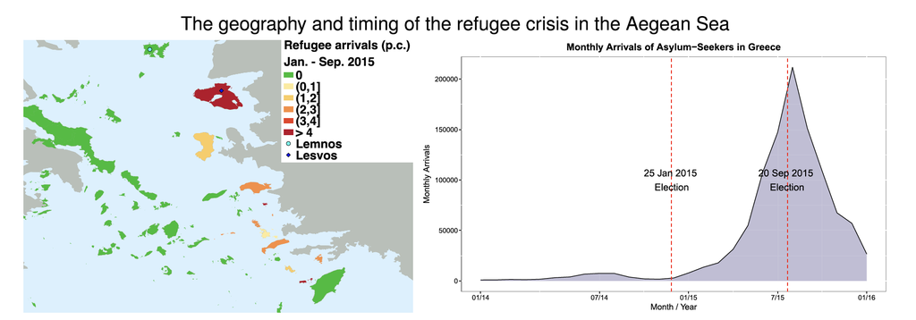

### Timing

- The refugee crisis started in the spring of 2015.
- Greece held an election in September 2015, right after the first major wave of refugee arrivals. This is coded as 1 on the `post` variable (post-treatment) and indicated as year 2016 (note that for the sake of simplicity, we code the early 2015 election as `2015`, and the late one as `2016`).
- The previous election had taken place only eight months prior in January 2015, before a significant number of refugees arrived (pre-treatment), which is coded in the data as year 2015.
- Two more elections were held in 2012. The election in May 2012 is coded as 2012 and the election in June 2012 is coded as 2013 (again, this is solely for the sake of simplicity).
- The unit of analysis are municipalities in Greece.

Now let’s familiarise ourselves with the data. A description of some of the variables that we will use today is below:

| Variable | Description |
| --- | --- |
| `Year` | Election year from 2012 to 2016 |
| `municipality` | Municipality ID |
| `post` | A post-treatment dummy variable that switches on for the year 2016 |
| `treatment` | A dummy variable indicating whether the municipality received refugees before the ‘2016’ election |
| `evertr` | Treatment variable indicating if the municipality received refugees (time-invariant) |
| `gdper` | Vote share for the Golden Dawn at the municipality level as percentage of total votes |

Now let’s load the data. There are two ways to do this:

You can load the dataset from your laptop using the `read_dta()` function. We will call this data frame **greekislands**.

```r
# Set your working directory
#setwd("~/Desktop/Causal Inference/2026/script6")
```

Or you can download the data from the course website from following url: https://github.com/bayreuth-politics/CI26/raw/main/docs/data/greekislands.dta.

Let’s start by checking our data as always.

**Exercise 1: Use the `head()` function to familiarise yourself with the data set.**

**Reveal Answer**

```r
head(greekislands)
```

```
# A tibble: 6 × 10
# Groups:   muni [2]
   year  muni treatment distance gdper  post  gddif evertr post2 treat
  <dbl> <dbl>     <dbl>    <dbl> <dbl> <dbl>  <dbl>  <dbl> <dbl> <dbl>
1  2012     1         0     240.  7.98     0 NA          0     0     0
2  2013     1         0     240.  7.28     0 -0.705      0     0     0
3  2015     1         0     240.  6.36     0 NA          0     1     0
4  2016     1         0     240.  7.62     1  1.25       0     1     0
5  2012     2         0     318.  2.58     0 NA          0     0     0
6  2013     2         0     318.  4.28     0  1.70       0     0     0
```

This is what we would expect. Recall that the `evertr` variable indicates municipalities that are treated at some point - independent of the timing -, while the `treatment` variable marks municipalities only *after* they were treated.

As we can see, the data set covers multiple election years. Before working with the data, let’s make sure we know how many and which elections are included in the data.

**Exercise 2: How many elections, i.e. `years` are covered by the data?**

**Reveal Answer**

```r
unique(greekislands$year)
```

```
[1] 2012 2013 2015 2016
```

Using the `unique` command, we find that four elections are covered by the data: the elections that are coded as having taking place in 2012, 2013, 2015, and 2016. We know from before that this refers to the two elections in 2012, and two further elections in 2015.

Let’s have a look at general voting patterns of the *Golden Dawn* over time, irrespective of treatment status of municipalities.

**Exercise 3: Plot the vote share of the Golden Dawn Party (`gdper`) over time.**

There are several ways to do this. For instance, you could plot the dispersion across municipalities by using the `boxplot` command or, alternatively, calculate average values per year. Feel free to pick the option you deem most appropriate.

**Reveal Answer**

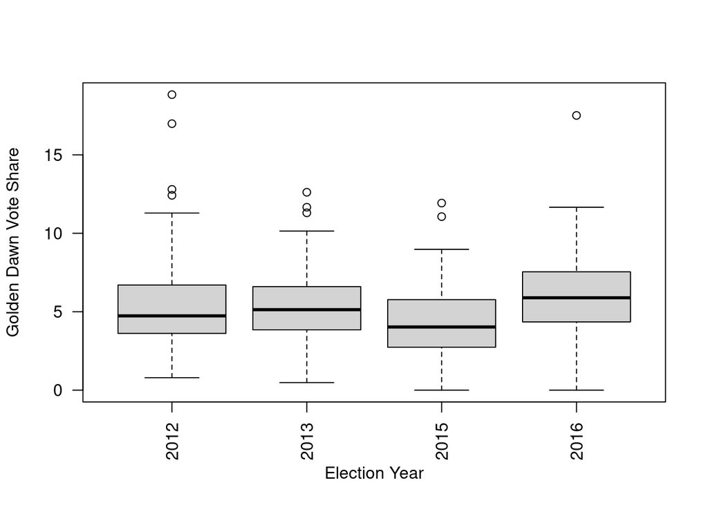

```r
# First option: Boxplot
boxplot(gdper ~ year,
        data = greekislands,
        xlab = "Election Year",
        ylab = "Golden Dawn Vote Share",
        las = 2) # This argument rotates the axis labels
```

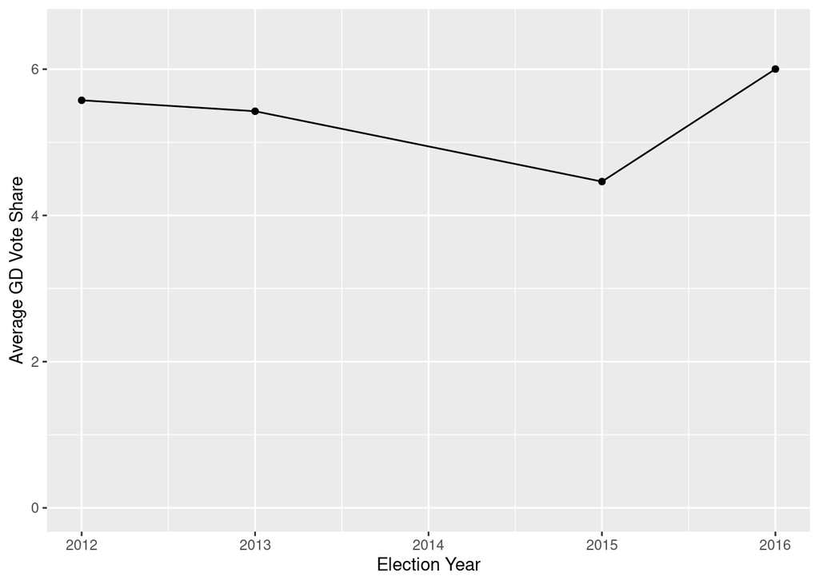

```r
# Second Option: Plot averages
# Calculating and storing means
average_data <- greekislands %>%
            group_by(year) %>%
            summarize(gd_averages = mean(gdper))

# Plotting means using ggplot

ggplot(average_data, aes(x = year, y = gd_averages)) +
  geom_point() + geom_line() + xlab("Election Year") + ylab("Average GD Vote Share") + ylim(0,6.5)
```

We can se that the vote share for the Golden Dawn party has remained somewhat stable between the 2012 and 2013 elections, and dropped in the 2015 election to an average value (per municipality) of `4.46%`. In the 2016 election, the party’s vote share rose substantively - to a new high of about `6%`.

## Difference-in-Differences

Being aware of the general trends of the Golden Dawn’s vote share is an important piece of information about context and the party’s history. However, it cannot tell us anything about the treatment effect we seek to analyse: the arrival of refugees in some Greek municipalities in the summer of 2015.

A naive observer might propose identifying this effect by looking at the differences between treated and untreated units in the post-treatment periods. Would this, however, be an appropriate representation of a possible treatment effect? It clearly would not! Only comparing post-treatment differences doesn’t allow us to account for unit/municipality-specific effects and voting patterns. Treatment, after all, was not assigned randomly, so we would almost inevitably pick up selection bias. We would not be able to say what is the effect of the treatment unless we can make a statement about how the treatment changed the outcome or resulted in the diversion from a previous trajectory. Using a *difference-in-differences* design allows us to do so, as you know, as long as critical assumptions hold.

**Exercise 4: Estimate the treatment effect by calculating the difference-in-differences between 2015 and 2016 using the `mean()` function.**

*Hint: Calculate the differences between treated and untreated units for the years 2015 and 2016 first.*

**Reveal Answer**

```r
# Difference in means between treated and untreated in 2016 (pot-treatment).
post_difference <- mean(greekislands$gdper[greekislands$evertr == 1 & greekislands$year == 2016]) -  mean(greekislands$gdper[greekislands$evertr == 0 & greekislands$year == 2016])
post_difference
```

```
[1] 2.744838
```

```r
# Difference in means between treated and untreated in 2015 (pre-treatment).
pre_difference <- mean(greekislands$gdper[greekislands$evertr == 1 & greekislands$year == 2015]) -    mean(greekislands$gdper[greekislands$evertr == 0 & greekislands$year == 2015])

pre_difference
```

```
[1] 0.6212737
```

```r
# Now calculate the difference between the two differences above
diff_in_diff <- post_difference - pre_difference
diff_in_diff
```

```
[1] 2.123564
```

The difference in the Golden Dawn’s vote share between treated and untreated municipalities increased in 2016. The difference-in-differences amount to `2.12`. This suggests that the treatment (i.e. the arrival of refugees) increased the vote share of the golden dawn by roughly `2%`-points in the affected municipalities.

While it is important to understand what exactly the difference-in-differences means, we usually do not have to calculate it manually. In fact, we can simply use an OLS to estimate a difference-in-differences design.

**Exercise 5: Estimate the difference-in-difference between 2015 and 2016 using an OLS regression.**

**Hint**

You can run a simple OLS with the interaction term of *treat* and a dummy variable for the post-treatment period as independent variables. However, you should restrict the data to the years 2015 and 2016, specifying `data = greekislands[greekislands$year>=2015,]` as argument for your OLS.

**Reveal Answer**

```r
ols_did <- lm_robust(gdper ~ evertr * post, data = greekislands[greekislands$year>=2015,])
summary(ols_did)
```

```
Call:
lm_robust(formula = gdper ~ evertr * post, data = greekislands[greekislands$year >=
    2015, ])

Standard error type:  HC2

Coefficients:
            Estimate Std. Error t value  Pr(>|t|) CI Lower CI Upper  DF
(Intercept)   4.3854     0.2221 19.7409 1.045e-47   3.9471    4.824 188
evertr        0.6213     0.7996  0.7769 4.382e-01  -0.9561    2.199 188
post          1.2737     0.3190  3.9935 9.333e-05   0.6445    1.903 188
evertr:post   2.1236     1.3052  1.6270 1.054e-01  -0.4511    4.698 188

Multiple R-squared:  0.1762 ,   Adjusted R-squared:  0.163
F-statistic: 9.036 on 3 and 188 DF,  p-value: 1.279e-05
```

The estimate for the interaction term, i.e. treated units after they were treated, corresponds to the result of the manually calculated difference-in-differences. As you can see, the OLS provides exactly the same point estimate as the manual calculation of the difference-in-differences, `2.12` - however, the OLS also provides measures of uncertainty, showing us that the estimate is just not statistically significant at conventional levels. The OLS provides quite intuitive estimates: the intercept corresponds to the Golden Dawn’s vote share in untreated municipalities in 2015. Treated municipalities had, on average, a higher vote share for the party by roughly `0.62`%points even before treatment. The parties vote share increased by about `1.27`%-points in untreated municipalities in 2016.

Note that there are multiple ways to calculate the difference-in-differences. Fixed effects are usually the preferred approach as they provide the most flexible (e.g. in terms of multiple time periods) and most efficient estimator. Let’s therefore calculate a fixed effects model for the same difference-in-differences as in Exercise 5.

**Exercise 6: Estimate the difference-in-differences between 2015 and 2016 using a fixed effects regression.**

*Hint: You can use either `lm_robust()`, `plm()` or `lm()` with dummy variables.*

**Reveal Answer**

```r
# lm_robust
fe_robust <- lm_robust(gdper ~ evertr*post, fixed_effects= factor(muni), data=greekislands[greekislands$year>=2015,])
summary(fe_robust)
```

```
Call:
lm_robust(formula = gdper ~ evertr * post, data = greekislands[greekislands$year >=
    2015, ], fixed_effects = factor(muni))

Standard error type:  HC2

Coefficients: (1 not defined because the design matrix is rank deficient)
            Estimate Std. Error t value  Pr(>|t|) CI Lower CI Upper DF
evertr            NA         NA      NA        NA       NA       NA NA
post           1.274    0.09139  13.938 1.333e-24    1.092    1.455 94
evertr:post    2.124    0.39686   5.351 6.152e-07    1.336    2.912 94

Multiple R-squared:  0.9651 ,   Adjusted R-squared:  0.9292
Multiple R-squared (proj. model):  0.7791 , Adjusted R-squared (proj. model):  0.5511
F-statistic (proj. model):    NA on 2 and 94 DF,  p-value: NA
```

```r
# plm
# note that we only specify the unit indicator in the index argument. We do this as we are only looking at two time periods here, but you should generally always specify both index variable when running FE models to avoid confusion.
fe_plm <- plm(gdper ~ evertr*post, model = "within", index = c("muni"), data=greekislands[greekislands$year>=2015,])
summary(fe_plm)
```

```
Oneway (individual) effect Within Model

Call:
plm(formula = gdper ~ evertr * post, data = greekislands[greekislands$year >=
    2015, ], model = "within", index = c("muni"))

Balanced Panel: n = 96, T = 2, N = 192

Residuals:
    Min.  1st Qu.   Median  3rd Qu.     Max.
-1.28954 -0.27782  0.00000  0.27782  1.28954

Coefficients:
            Estimate Std. Error t-value  Pr(>|t|)
post        1.273734   0.099336 12.8225 < 2.2e-16 ***
evertr:post 2.123564   0.280964  7.5581  2.67e-11 ***
---
Signif. codes:  0 '***' 0.001 '**' 0.01 '*' 0.05 '.' 0.1 ' ' 1

Total Sum of Squares:    176.35
Residual Sum of Squares: 38.957
R-Squared:      0.77909
Adj. R-Squared: 0.55113
F-statistic: 165.754 on 2 and 94 DF, p-value: < 2.22e-16
```

```r
fe_dummy <- lm(gdper ~ evertr * post + factor(muni), data = greekislands[greekislands$year>=2015,])
summary(fe_dummy)
```

```
Call:
lm(formula = gdper ~ evertr * post + factor(muni), data = greekislands[greekislands$year >=
    2015, ])

Residuals:
    Min      1Q  Median      3Q     Max
-1.2895 -0.2778  0.0000  0.2778  1.2895

Coefficients: (1 not defined because of singularities)
               Estimate Std. Error t value Pr(>|t|)
(Intercept)     6.35368    0.45792  13.875  < 2e-16 ***
evertr         -2.69291    0.65892  -4.087 9.20e-05 ***
post            1.27373    0.09934  12.822  < 2e-16 ***
factor(muni)2  -3.78604    0.64377  -5.881 6.20e-08 ***
factor(muni)3  -1.55751    0.64377  -2.419 0.017472 *
factor(muni)4  -3.10872    0.64377  -4.829 5.31e-06 ***
factor(muni)5  -1.22008    0.64377  -1.895 0.061138 .
factor(muni)6   1.06490    0.64377   1.654 0.101431
factor(muni)7  -1.13881    0.64377  -1.769 0.080143 .
factor(muni)8  -4.10152    0.64377  -6.371 6.88e-09 ***
factor(muni)9  -1.05344    0.64377  -1.636 0.105109
factor(muni)10 -2.66002    0.64377  -4.132 7.80e-05 ***
factor(muni)11  0.54228    0.64377   0.842 0.401730
factor(muni)12 -2.99074    0.64377  -4.646 1.10e-05 ***
factor(muni)13 -6.99054    0.64377 -10.859  < 2e-16 ***
factor(muni)14 -2.18372    0.64377  -3.392 0.001016 **
factor(muni)15 -4.63345    0.64377  -7.197 1.48e-10 ***
factor(muni)16 -4.98236    0.64377  -7.739 1.12e-11 ***
factor(muni)17 -5.23368    0.64377  -8.130 1.70e-12 ***
factor(muni)18 -3.42812    0.64377  -5.325 6.86e-07 ***
factor(muni)19 -3.48572    0.64377  -5.415 4.69e-07 ***
factor(muni)20  0.73748    0.64377   1.146 0.254884
factor(muni)21 -0.23429    0.64377  -0.364 0.716720
factor(muni)22  2.13230    0.64377   3.312 0.001315 **
factor(muni)23 -1.23974    0.64377  -1.926 0.057158 .
factor(muni)24 -3.75036    0.64377  -5.826 7.92e-08 ***
factor(muni)25 -0.93581    0.64377  -1.454 0.149375
factor(muni)26  0.44822    0.64377   0.696 0.487996
factor(muni)27 -3.71715    0.64377  -5.774 9.93e-08 ***
factor(muni)28 -2.61289    0.64377  -4.059 0.000102 ***
```

[output cut: 60 more lines]

```
factor(muni)89 -5.22449    0.64377  -8.115 1.83e-12 ***
factor(muni)90 -1.68049    0.64377  -2.610 0.010525 *
factor(muni)91       NA         NA      NA       NA
factor(muni)92  1.09935    0.64377   1.708 0.090996 .
factor(muni)93 -1.90673    0.64377  -2.962 0.003873 **
factor(muni)94 -2.30515    0.64377  -3.581 0.000545 ***
factor(muni)95 -3.84034    0.64377  -5.965 4.27e-08 ***
factor(muni)96 -2.36403    0.64377  -3.672 0.000399 ***
evertr:post     2.12356    0.28096   7.558 2.67e-11 ***
---
Signif. codes:  0 '***' 0.001 '**' 0.01 '*' 0.05 '.' 0.1 ' ' 1

Residual standard error: 0.6438 on 94 degrees of freedom
Multiple R-squared:  0.9651,    Adjusted R-squared:  0.9292
F-statistic: 26.83 on 97 and 94 DF,  p-value: < 2.2e-16
```

## Generalised Diff-in-Diff

Let’s now extend our analysis by including all pre-treatment periods in our analysis. The easiest way to do so is running a two-way fixed effects regression.

**Exercise 7: Estimate the difference-in-differences using a two-way Fixed Effects regression with all time periods and `treatment` as independent variable.**

**Reveal Answer**

```r
twoway_FE <- plm(gdper ~ treatment, effect="twoways",model="within",index=c("muni","year"), data=greekislands)
summary(twoway_FE)
```

```
Twoways effects Within Model

Call:
plm(formula = gdper ~ treatment, data = greekislands, effect = "twoways",
    model = "within", index = c("muni", "year"))

Balanced Panel: n = 96, T = 4, N = 384

Residuals:
      Min.    1st Qu.     Median    3rd Qu.       Max.
-4.5964070 -0.5205535 -0.0089621  0.4459476  7.0013287

Coefficients:
          Estimate Std. Error t-value  Pr(>|t|)
treatment  2.08700    0.39328  5.3066 2.253e-07 ***
---
Signif. codes:  0 '***' 0.001 '**' 0.01 '*' 0.05 '.' 0.1 ' ' 1

Total Sum of Squares:    380.22
Residual Sum of Squares: 345.92
R-Squared:      0.090211
Adj. R-Squared: -0.22693
F-statistic: 28.1603 on 1 and 284 DF, p-value: 2.2526e-07
```

As you can see, the estimate is now slightly smaller than the one we got by comaparing 2015 and 2016 only. This is not surprising as the regression considers all pre-treatment periods now and, therefore, attributes some of the variance to other factors such as unit-specific trends. However, it is noteworthy that the change is negligible. We still estimate that the treatment effect, or ATT, is roughly above 2%-points.

**Exercise 8: Calculate robust standard errors for (i) the plm FE model, (ii) the two-way FE model and present the regression output in a single table. Include the simple OLS model in the table.**

*Note: There is no need to adjust standard errors after using `lm_robust()` as the command does that automatically.*

**Reveal Answer**

```r
### ADJUSTING STANDARD ERRORS
## plm FE model
fe_plm_se <- coeftest(fe_plm, vcov =
                        vcovHC(fe_plm,
                               type = "HC1",
                               cluster = "group"))
fe_plm_se
```

```
t test of coefficients:

            Estimate Std. Error t value  Pr(>|t|)
post        1.273734   0.091318 13.9483 < 2.2e-16 ***
evertr:post 2.123564   0.382751  5.5482 2.649e-07 ***
---
Signif. codes:  0 '***' 0.001 '**' 0.01 '*' 0.05 '.' 0.1 ' ' 1
```

```r
## two-way FE model

twoway_FE_se <- coeftest(twoway_FE, vcov =
                           vcovDC(twoway_FE,
                                  type = "HC1"))
twoway_FE_se
```

```
t test of coefficients:

          Estimate Std. Error t value  Pr(>|t|)
treatment  2.08700    0.13708  15.225 < 2.2e-16 ***
---
Signif. codes:  0 '***' 0.001 '**' 0.01 '*' 0.05 '.' 0.1 ' ' 1
```

```r
## CREATING A REGRESSION TABLE

screenreg(l=list(ols_did, fe_plm_se, twoway_FE_se),
          custom.header = list("OLS (2-period)" = 1, "FE (2-period)" = 2, "2-way FE" = 3),
          include.ci=c(FALSE, FALSE, FALSE),
          custom.coef.map = list("treatment" = "Treatment", "evertr:post" = "Treatment", "evertr:postTRUE" = "Treatment"))
```

```
========================================
           OLS (2-  FE (2-per   2-way FE
           -------  ---------  ---------
           Model 1  Model 2    Model 3
----------------------------------------
Treatment    2.12    2.12 ***   2.09 ***
            (1.31)  (0.38)     (0.14)
----------------------------------------
R^2          0.18
Adj. R^2     0.16
Num. obs.  192
RMSE         2.21
========================================
*** p < 0.001; ** p < 0.01; * p < 0.05
```

# Pararell trends

As we know, we cannot test whether parallel trends hold, but we can conduct some visual inspections and statistical analyses. One way to do this is to plot the outcome variable for both treated and untreated units overtime before the intervention. In the best case, this lends plausibility to the assumption.

Let’s first get the mean vote share for the Golden Dawn for the treated and untreated units. Let’s do so using Tidyverse because this will allow us to directly work with the data. We will be using the `group_by()` and `summarise()` functions. You can of course do all of the following calculations in base R as well, and use the `mean` function you already know to achieve this - give it a try!

**Exercise 9: Calculate the mean vote share for the Golden Dawn for the treated and the untreated units for all the elections. Store this into a new data frame and call it `plot.parallel`. Use tidy to create this new data frame. You can find the syntax and the description of the functions below:**

```r
new.data <- data %>%
  group_by(variable_1, variable_2) %>%
  summarise(new_variable = mean(outcome, na,rm = TRUE)) %>%
  mutate(condition = ifelse(evertr == 1, "Treatment", "Control") )
```

| Function | Description |
| --- | --- |
| `new data <- dataframe` | Assignment operator where the new data frame will be stored |
| `group_by()` | Group observations by a variable or set of variables |
| `summarise()` | Creates a new data frame with one ore more rows of each combination of grouping variables |
| `mutate()` | Create new variables or modify existing ones |

**Reveal Answer**

```r
plot.parallel <- greekislands %>%
  group_by(evertr, year) %>%
  summarise(vote = mean(gdper)) %>%
  mutate(condition = ifelse(evertr == 1, "Treatment", "Control"))

head(plot.parallel)
```

```
# A tibble: 6 × 4
# Groups:   evertr [2]
  evertr  year  vote condition
   <dbl> <dbl> <dbl> <chr>
1      0  2012  5.49 Control
2      0  2013  5.34 Control
3      0  2015  4.39 Control
4      0  2016  5.66 Control
5      1  2012  6.16 Treatment
6      1  2013  6.02 Treatment
```

We can see now that we have the average vote share for treated and untreated units for every election year. For example, we can see that the average vote share for the Golden Dawn in untreated islands was `5.34` for the 2013 election.

Right, so we see that we have the average vote share for treated and untreated units for each election from 2012 to 2016. Now, let’s plot the trends before and after the intervention.

**Exercise 10: Plot the parallel trends. Set vote share for the Golden Dawn as the outcome on the y-axis, `year` on the x-axis. Connect the data points of the two groups using a line. Place the legend of your plot at the bottom. Change the default colour and use the Wes Anderson Palette. Below you will find all the functions necessary to generate this plot. Remember to use the plus sign between functions.**

| Function | Description |
| --- | --- |
| `ggplot(aes(x = , y =, colour = ), data = )` | map data components into the graph |
| `geom_point()` | To generate a scatterplot |
| `scale_color_manual(values=wes_palette("Royal1"))` | Replace the default colour palette |
| `theme(legend.position = "bottom")` | To place the legend at the bottom |
| `geom_line(aes(x=year,y=vote, color = condition, group = condition))` | To connect the dots with lines by group |
| `labs(x="", y="", title="")` | Add/adjust labels and title |

**Reveal Answer**

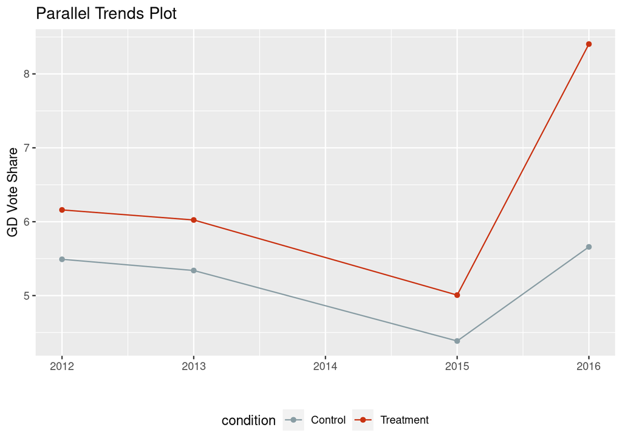

```r
ggplot(aes(x = year, y = vote, colour = condition), data = plot.parallel) +
  geom_point() +
  scale_color_manual(values=wes_palette("Royal1")) +
  theme(legend.position = "bottom") +
  geom_line(aes(x=year,y=vote, color = condition, group = condition)) +
  labs(x = "", y="GD Vote Share", title="Parallel Trends Plot")
```

The plot suggests that parallel trends assumption would hold in this case. The vote share for the Golden Dawn follows a similar path for treated and untreated units for at least three elections before the intervention.

Now let’s look at the leads to identify any potential anticipatory effects. Let’s imagine that the Golden Dawn back in 2012 believed that there was going to be a major humanitarian crisis in the future. Suppose they then thought that they could exploit this situation to increase their electoral gains by redirecting their campaigning and funding efforts. In that case, we wouldn’t be able to disentangle whether changes in vote share are due to the previous campaigning efforts on the part of the Golden Dawn or due to the actual influx of asylum seekers to Greece. We can use leads to identify if there are any anticipatory effects. If we find systematic differences between treated and untreated units, this would suggest that units in one or both groups are responding to the treatment before receiving it.

**Exercise 11: Create dummy year variables equal to `1` for every year and only for treated municipalities. Call this variable leads, plus the year. For example, `lead2012` will take a value of `1` only for treated municipalities and only for observations of these municipalities in the year 2012. You can see an example below. You can use the `mutate()` and/or the `ifelse()` functions to create these new variables. The syntax of the `ifelse()` function is the following: `new variable = ifelse(condition, "value if condition is met", "value if the condition is not met")`. Create these dummy variables for the elections in 2012, 2013, and 2015.**

```r
greekislands <- greekislands %>%
  mutate(lead2012 = ifelse(evertr == 1 & year == 2012, 1, 0))
```

**Reveal Answer**

```r
table(greekislands$year)
```

```
2012 2013 2015 2016
  96   96   96   96
```

```r
greekislands <- greekislands %>%
  mutate(lead2012 = ifelse(evertr == 1 & year == 2012, 1, 0),
         lead2013 = ifelse(evertr == 1 & year == 2013, 1, 0),
         lead2015 = ifelse(evertr == 1 & year == 2015, 1, 0))
```

Now that we have created these dummy variables, we can run a two-way fixed effect model and see if they are anticipatory effects.

**Exercise 12: Conduct the same two-way fixed-effect model that we estimated before, but rather than using the `treatment` variable, replace this variable with the new leads variables that you just created. Run separate estimations for each lead. Exclude the actual treatment period from the models by setting `data = greekislands[greekislands$year<=2015,]`. By doing this, the results of the leads models are not contaminated by the actual treatment effect. Store the outputs of these regressions into different objects. Does the evidence suggest that there are any anticipatory effects? Are the results of these three models statistically significant? You can use the summary() or screenreg() functions to take a look at your results.**

**Reveal Answer**

```r
lead2012 <- plm(gdper ~ lead2012, model = "within", effect = "twoways",
           index = c("muni", "year"), data = greekislands[greekislands$year<=2015,])

lead2013 <- plm(gdper ~ lead2013, model = "within", effect = "twoways",
           index = c("muni", "year"), data = greekislands[greekislands$year<=2015,])

lead2015 <- plm(gdper ~ lead2015, model = "within", effect = "twoways",
           index = c("muni", "year"), data = greekislands[greekislands$year<=2015,])



# Did you remember to adjust SEs?

lead2012se <- coeftest(lead2012, vcov =
                           vcovDC(lead2012,
                                  type = "HC1"))

lead2013se <- coeftest(lead2013, vcov =
                           vcovDC(lead2013,
                                  type = "HC1"))

lead2015se <- coeftest(lead2015, vcov =
                           vcovDC(lead2015,
                                  type = "HC1"))
```

The evidence gathered from the three models suggests there are no anticipatory effects. We don’t find any statistically significant dynamics between treated and untreated municipalities on the vote share for the Golden Dawn before the 2016 election, which is good!

Now, let’s plot all the two-way fixed effects models where we used the `plm()` function into a single figure.

**Exercise 13: Plot the coefficients from the leads models, plus the two-way fixed model for the 2016 election that you estimated in Exercise 7 (`twoway_FE`). Use the `modelplot()` function to generate this plot. Feed in a list of models, e.g., “list(model1, model2…)”. Enter the unadjusted models. The function allows you to adjust standard errors directly, and you can do so using the `vcov=` argument, specifying `vcovDC` in this case. In addition, include the `coord_flip()` function. This function will flip the cartesian coordinates of the plot, so we have the models (years) on the x-axis and the coefficients on the y axis. Remember to add plus sign operators between two functions. You can also add the `xlab("Year")` function to add a custom label to the x-axis.**

**Reveal Answer**

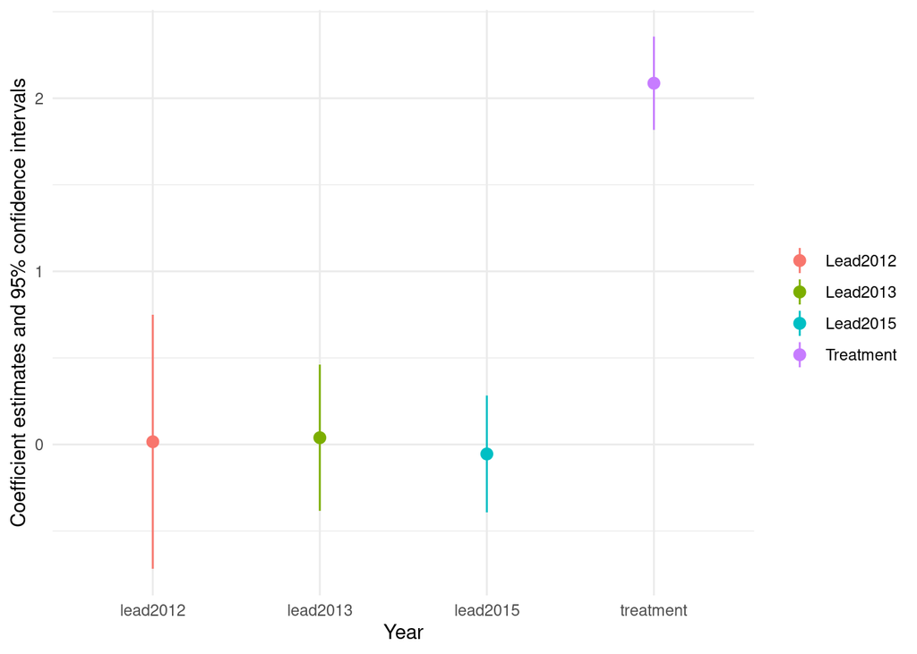

```r
modelplot(list("Lead2012"=lead2012, "Lead2013"=lead2013, "Lead2015"=lead2015, "Treatment"=twoway_FE),
          vcov = vcovDC) +
  coord_flip() +
  ylab("Year")
```

Again, we can observe that the pre-treatment coefficients are nearly zero and not statistically significant, but then for the ‘2016’ election, we find that the vote share for Golden Dawn has risen substantially in treated units as opposed to untreated ones. Thus, we can be pretty confident that the increase in vote share was indeed caused by the influx of refugees into the Greek islands - and not by any anticipation effects.

## Placebo test

We can further conduct a placebo test to evaluate whether the parallel trend assumption is likely to hold. Recall that we are trying to show that there is no clear difference in trajectories between treated and untreated municipalities. This complements our test on anticipation, now we are testing whether there is an unexpected difference between any two pre-treatment periods.

The steps to conduct this are the following:

1. Use data for any two periods that came before the treatment was implemented/happened.
2. Create a dummy variable for each before treatment that is equal to 1 only for that specific year and only for treated units (just as we did before for leads).
3. Estimate the difference-in-difference using the `plm()` or `lm_robust()` function.
4. If you find statistically significant results, this may suggest a violation of parallel trends.

**Exercise 14: Drop all the observations of the year of the intervention (2016). Do this using the `filter()` function or subset the data frame. Then, create a fake treatment variable and call it `post2` and set it equal to 1 for all observations in the year 2015. This variable would indicate the hypothetical case of a municipality receiving refugees before the first 2015 election. You can see an example below.**

```r
greekislands <- greekislands %>%
  filter(variable != year) %>%
  mutate(new.variable = ifelse(year variable == "year", 1, 0))
```

**Reveal Answer**

```r
table(greekislands$year)
```

```
2012 2013 2015 2016
  96   96   96   96
```

```r
greekislands <- greekislands %>%
  filter(year != 2016) %>%
  mutate(post2 = ifelse(year == "2015", 1, 0))
```

Great! Now let’s use this dummy variable to perform the placebo test. We are essentially going to test that there are no differential trends between treated and untreated units, somewhat as we did before when we looked at anticipatory trends. Now we’re comparing two periods directly.

**Exercise 15: Conduct the same two-way fixed effect model as above using the `plm()` or `lm_robust()` function and use the `post2` variable, but subset the data so one model will only conduct the placebo test using the 2012 and 2015 elections, and another model only using the observations from the 2013 and 2015 elections. Store the models in a list and plug this list inside of the `modelsummary(list)` function to report your results. Did you find statistically significant differences between treated and untreated units pre-treatment? Below, you can see an example of how to store multiple models in a list (`list()`).**

```r
models <- list(
    "plm"= lm(outcome ~ treatment, model = "within", effect = "twoways", index = c("muni", "year"), data = data[data$year != year,]),
    "lm" = lm(outcome ~ outcome, data = data, subset=(year!=year)), # set year equal to year that you want to exclude.
    "lm_robust" = lm_robust(outcome ~ treatment, data = data[data$year != year,], cluster = unit)) # set year equal to year that you want to exclude.
```

**Reveal Answer**

```r
models <- list(
     "1215"=lm_robust(gdper ~ evertr + post2+evertr*post2, data = greekislands, subset=(year!=2013), cluster=muni), # placebo test 2012 and 2015
    "1315" = lm_robust(gdper ~ evertr + post2+evertr*post2, data = greekislands, subset=(year!=2012),cluster=muni)) # placebo test 2013 and 2015


modelsummary(models)
```

|  | 1215 | 1315 |
| --- | --- | --- |
| (Intercept) | 5.491 | 5.339 |
|  | (0.334) | (0.261) |
| evertr | 0.668 | 0.684 |
|  | (1.127) | (0.651) |
| post2 | −1.106 | −0.954 |
|  | (0.227) | (0.126) |
| evertr × post2 | −0.047 | −0.063 |
|  | (0.601) | (0.403) |
| Num.Obs. | 192 | 192 |
| R2 | 0.048 | 0.054 |
| R2 Adj. | 0.033 | 0.038 |
| Std.Errors | by: muni | by: muni |

We find that there are no systematic differences between treated and untreated municipalities as we find near zero coefficients and conclude there are no effects whatsoever. While not conclusive, the analyses and placebo checks have made us feel comfortable about the plausibility of the parallel trends assumption. By and large, there was no distinct trajectory between treated and untreated units before the second 2015 (or ‘2016’) election.